# 課題12

###### 演習1

磁気浮上系$P(s)$は安定なシステムか, それとも不安定なシステムか. 理由も併せて判別せよ.

伝達関数の分母を展開すると,

\begin{eqnarray} P(s) = \frac{K_i}{ML_ms^3 + MR_ms^2 - K_xL_ms - K_xR_m} \nonumber \end{eqnarray}

となる．

この時, 係数が負である項が存在するため, 安定の必要条件を満たさない．よって不安定である．

###### 演習2

フィードバック制御系の一巡伝達関数$L(s) =P(s)K(s)$と閉ループ伝達関数$G(s)$を求めよ. 分母は$s$について降べきの順で整理した形にすること．

\begin{eqnarray} L(s) &=& K(s)P(s) = \frac{K_iK_Ds + K_iK_P}{ML_ms^3 + MR_ms^2 - K_xL_ms - K_xR_m} \nonumber\\ \\ G(s) &=& \frac{L(s)}{1 + L(s)} = \frac{K_iK_Ds + K_iK_P}{ML_ms^3 + MR_ms^2 + (K_iK_D - K_xL_m)s + (K_iK_P - K_xR_m)} \nonumber \end{eqnarray}

###### 演習3

これらのパラメータを代入した一巡伝達関数$L(s)$と閉ループ伝達関数$G(s)$の式を書き下せ．

\begin{eqnarray} L(s) &=& \frac{3K_Ds + 3K_P}{0.01s^3 + 0.3s^2 - 50s - 1500} \nonumber\\ \\ G(s) &=& \frac{3K_Ds + 3K_P}{0.01s^3 + 0.3s^2 + (3K_D - 50)s + (3K_P - 1500)} \nonumber \end{eqnarray}

###### 演習4

ラウス＝フルビッツの安定判別法のどちらかを用いて, フィードバック制御系$G(s)$が安定となるための$K_P$と$K_D$の範囲を求め, 横軸を$K_P$, 縦軸を$K_D$としたグラフ上でその範囲を図示せよ.

今回はフルビッツ法を使って$K_P$と$K_D$の範囲を求める．

「特性多項式の係数が全て存在し，正である」と仮定するため，$\displaystyle　K_D > \frac{50}{3}$，$\displaystyle K_P > 500$となる．

フルビッツ行列$H$は以下のようになる．

$H=\begin{pmatrix} 0.3 & 3K_P - 1500 & 0 \\ 0.01 & 3K_D - 50 & 0 \\ 0 & 0.3 & 3K_P - 1500 \end{pmatrix}$

また，フルビッツ小行列$H_1，H_2$は以下のようになる．

$H_1=0.3 > 0$

$H_2=\begin{vmatrix} 0.3 & 3K_P-1500 \\ 0.01 & 3K_D - 50 \end{vmatrix} =0.9K_D - 15 - (0.03K_P - 15) = 0.9K_D - 0.03K_P$

$H_2 > 0$となる条件は$\displaystyle K_D > \frac{1}{30}K_P$

よって，$G(s)$が安定となるための$K_P$と$K_D$の範囲は，

$ \left\{ \begin{array}{l} \displaystyle K_D > \frac{1}{30}K_P \\ K_P > 500 \end{array} \right. $

となる．

###### 演習5

演習4で求めた範囲を参照し, 安定なはずの$K_P$, $K_D$について, ナイキストの安定判別法で安定性を確認せよ.

```python
import numpy as np
from control.matlab import *
```

```python
K_P, K_D = 600, 25
n = [3 * K_D, 3 * K_P]
d = [0.01, 0.3, -50, -1500]
L = tf(n, d)
```

```python
pole(L)
```

```
array([ 70.71067812, -70.71067812, -30.        ])
```

実部が正の極の数$U = 1$

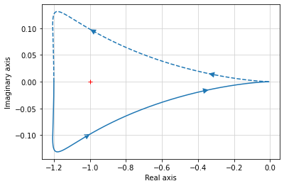

```python
real, imag, w = nyquist(L)
```

点（-1, 0）を反時計回りに回る回数$N = 1$

よって, $N = U$より, フィードバック制御は安定である．

###### 演習6

演習4で求めた範囲を参照し, 安定な場合と安定じゃない場合の$K_P$, $K_D$を選び, それぞれについてステップ応答を確認せよ.

```python
import matplotlib.pyplot as plt
```

```python
K_P_1, K_D_1 = 600, 25
K_P_2, K_D_2 = 600, 15

n_G_1 = [3 * K_D_1, 3 * K_P_1]
n_G_2 = [3 * K_D_2, 3 * K_P_2]

d_G_1 = [0.01, 0.3, 3 * K_D_1 - 50, 3 * K_P_1 -1500]
d_G_2 = [0.01, 0.3, 3 * K_D_2 - 50, 3 * K_P_2 -1500]

G_1 = tf(n_G_1, d_G_1)
G_2 = tf(n_G_2, d_G_2)
```

```python
t = np.linspace(0, 1, 100)
```

```python
y_1, t = step(G_1, t)
y_2, t = step(G_2, t)
```

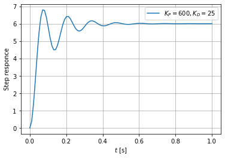

```python
plt.plot(t, y_1, label="$K_P = 600, K_D = 25$")
plt.xlabel("$t$ [s]")
plt.ylabel("Step responce")
plt.legend()
plt.grid()
plt.show()
```

$K_P = 600, K_D = 25$は安定な場合の値なので，ステップ応答の振動は次第に緩やかになる．

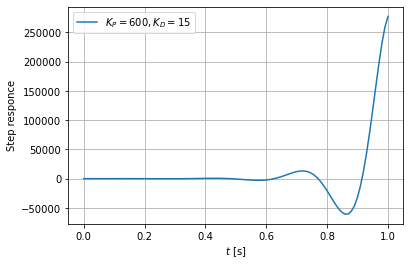

```python
plt.plot(t, y_2, label="$K_P = 600, K_D = 15$")
plt.xlabel("$t$ [s]")
plt.ylabel("Step responce")
plt.legend()
plt.grid()
plt.show()
```

$K_P = 600, K_D = 15$は不安定な場合の値なので，ステップ応答の振動は発散する．

###### 演習7

演習3で求めた閉ループ伝達関数$G(s)$を元に, 目標値を1とした場合, つまり$u(t) = 1$（ステップ入力）とした場合の$\delta x(t)$の最終値$x_\infty$を$K_P$, $K_D$の式で求めよ. （$L[\delta x(t)] = X(s) = G(s)U(s)$である）

\begin{eqnarray} x_\infty &=& \lim_{t \to \infty}\delta x(t) \nonumber\\ &=& \lim_{s \to 0}sX(s) \nonumber\\ &=& \lim_{s \to 0}sG(s)U(s) \nonumber\\ &=& \lim_{s \to 0}G(s) \nonumber\\ &=& \frac{3K_P}{3K_P - 1500} \nonumber\\ &=& \frac{K_P}{K_P - 500} > 1 \nonumber \end{eqnarray}

###### 任意課題：式(1)の微分方程式から式(2)の伝達関数を導出せよ．

$X(s) = \mathcal{ L }[\delta x(t)]$，$V(s) = \mathcal{ L }[\delta v(t)]$，$I(s) = \mathcal{ L }[\delta i(t)]$として(1)式をラプラス変換すると，

\begin{eqnarray} M\{s^2X(s)-s\delta x(0) - \delta' x(0)\} &=& K_xX(s) + K_iI(s)\nonumber\\ L_m\{sI(s) - \delta i(0)\} + R_mI(s) &=& V(s)\nonumber \end{eqnarray}

となる．

この時，$x(0) = x_0，i(0) = i_0，v(0) = v_0$であることから，$\delta x(0) = \delta' x(0) = \delta i(0) = 0$となるので，

\begin{eqnarray} Ms^2X(s) &=& K_xX(s) + K_iI(s)\nonumber\\ L_msI(s) + R_mI(s) &=& V(s)\nonumber \end{eqnarray}

となる．

$X(s)，V(s)$について整理すると，以下のようになる．

\begin{eqnarray} X(s) &=& \frac{K_iI(s)}{Ms^2 - K_x}\nonumber\\ V(s) &=& (L_ms + R_m)I(s)\nonumber \end{eqnarray}

$P(s) = X(s)\ /\ V(s)$として伝達関数を計算すると以下のようになる．

\begin{eqnarray} P(s) = X(s)\ / \ V(s) = \frac{K_i}{(Ms^2 - K_x)(L_ms + R_m)}\nonumber \end{eqnarray}